[Student Id]  
Member #1: Van Pham, s3788106  
Member #2: Sean Tan, s3806690  
Member #3: Sunny Thai, s3657606

# Predicting Points From Seasonal Performance

## Overview

### Data source

The data we are using is from:  
https://www.kaggle.com/drgilermo/nba-players-stats-20142015/download  
The dataset is of the stats of players in the NBA from 2014 - 2015 and has 490 observations and consists of 1 target feature and 33 descriptive features.

### Project Objective

We attempt to predict the scores of an NBA player based on the 2014-2015 end of season player statistics through regression analysis

### Target Feature

Our target feature is 'PTS', which is a regression problem as it's a continuous numerical feature

### Descriptive Features

Name: ID like  
Games Played: Continuous  
MIN: Continuous  
FGM: Continuous  
FGA: Continuous  
FG%: Percentage  
3PM: Continuous  
3PA: Continuous  
3P%: Percentage  
FTM: Continuous  
FTA: Continuous  
FT%: Percentage  
OREB: Continuous  
DREB: Continuous  
REB: Continuous  
AST: Continuous  
STL: Continuous  
BLK: Continuous  
TOV: Continuous  
PF: Continuous  
EFF: Continuous  
AST/TOV: Continuous  
STL/TOV: Continuous  
Age: Continuous  
Birth_Place: us, do, ua, ru, fr, it, au, ca, nz, gb, cd, ba, br, de, ch, hr, lt, tr, ng, il, gr, si, sn, ve, pr, se, jm, mx, es, gf, cm, ar, ss, pl, me, mk, ht, cg, vi, be, ge.  
Birthdate: Dates  
Collage: University of Connecticut, University of Oregon, University of Arizona, Michigan State University, University of Florida, University of Colorado, University of New Mexico, University of Maryland, Wake Forest University, University of California, University of Alabama, Duke University, University of Utah, St. Bonaventure University, University of Nevada, Las Vegas, University of Kentucky, Georgia Institute of Technology, Syracuse University, Washington State University, University of California, Los Angeles, Gonzaga University, University of Texas at Austin, University of Kansas, Florida State University, University of Oklahoma, Louisiana State University, Brigham Young University, University of North Carolina, University of Dayton, Stanford University, Providence College, University of Tennessee, Purdue University, Kansas State University, Blinn College, University of Memphis, Central Michigan University, Lehigh University, Wichita State University, Baylor University, Western Kentucky University, Weber State University, Villanova University, University of Michigan, Xavier University, Texas A&M University, University of Pittsburgh, University of Southern California, University of Missouri, University of Wisconsin, University of Iowa, Creighton University, Marquette University, University of Louisville, University of Louisiana at Lafayette, Indiana University, Virginia Polytechnic Institute and State University, Vanderbilt University, Towson University, Indiana University-Purdue University Indianapolis, Butler University, Georgetown University, California State University, Fresno, Belmont University, Murray State University, University of Washington, Northeastern University, University of Notre Dame, San Diego State University, Saint Joseph's University, California State University, Long Beach, Arizona State University, University of Miami, University of Arkansas, Oregon State University, Boston College, Ohio State University, University of Cincinnati, University of Nevada, Reno, Harvard University, University of Tulsa, North Carolina State University, University of Virginia, Oklahoma State University, Morehead State University, Old Dominion University, University of Georgia, Western Carolina University, Clemson University, University of Minnesota, Norfolk State University, Temple University, University of Tennessee at Martin, Saint Mary's College of California, St. John's University, University of Illinois at Urbana-Champaign, Bucknell University, Cleveland State University, Louisiana Tech University, La Salle University, University of Detroit Mercy, Tennessee State University, Eastern Washington University, Utah Valley State College, Seton Hall University, Western Michigan University,New Mexico State University, Davidson College, Pennsylvania State University,Virginia Commonwealth University, University of Montana, DePaul University  
Experience: 5, 6, R, 7, 10 , 3, 1, 2, 4, 9, 15, 8, 12, 11, 16, 14, 13, 19, 18, 17  
Height: Continuous  
Pos: PG, PF, C, SG, SF  
Team: PHO, CHI, ORL, ATL, CHA, NJN, UTA, CLE, NYK, NOH, DAL, POR, TOR, MIA, DET, GSW, WAS, OKC, MIN, SAS, BOS, SAC, LAC, PHI, IND, LAL, HOU, MEM, DEN, MIL  
Weight: Continuous  
BMI: Continuous

#### Some descriptive features are self-explanatory, except ones with 3-4 letter descriptions which unless you are a basketball fan.

MIN = Minutes Played  
(M)=made, (A)=attempted, (%)=percentage  
FG = Field Goal  
3P = 3 Point Field Goal  
FT = Free Throw  
REB = Rebound, (O)=Offensive, (D)=Defensive  
AST = Assists, STL = Steal, BLK = Block, TOV = Turnover, PF = Personal Fouls

# Data Preparation and Cleaning

```python
# Importing modules
import numpy as np
import pandas as pd
import matplotlib.pyplot as plt
import seaborn as sns
import statsmodels.api as sm
import statsmodels.formula.api as smf
import patsy
import warnings
###
warnings.filterwarnings('ignore')
###
%matplotlib inline
%config InlineBackend.figure_format = 'retina'
plt.style.use("ggplot")
```

```python
dp = pd.read_csv("players_stats.csv")
```

```python
dp.shape
```

```
(490, 34)
```

```python
dp.isnull().sum()
```

```
Name              0
Games Played      0
MIN               0
PTS               0
FGM               0
FGA               0
FG%               0
3PM               0
3PA               0
3P%               0
FTM               0
FTA               0
FT%               0
OREB              0
DREB              0
REB               0
AST               0
STL               0
BLK               0
TOV               0
PF                0
EFF               0
AST/TOV           0
STL/TOV           0
Age              68
Birth_Place      68
Birthdate        68
Collage         140
Experience       68
Height           68
Pos              68
Team             68
Weight           68
BMI              68
dtype: int64
```

```python
dp.describe(include='int64')
```

|  | Games Played | MIN | PTS | FGM | FGA | 3PM | 3PA | FTM | FTA | OREB | DREB | REB | AST | STL | BLK | TOV | PF | EFF |
| --- | --- | --- | --- | --- | --- | --- | --- | --- | --- | --- | --- | --- | --- | --- | --- | --- | --- | --- |
| count | 490.000000 | 490.000000 | 490.000000 | 490.000000 | 490.000000 | 490.000000 | 490.00000 | 490.000000 | 490.000000 | 490.000000 | 490.000000 | 490.000000 | 490.000000 | 490.000000 | 490.000000 | 490.000000 | 490.000000 | 490.000000 |
| mean | 53.014286 | 1214.714286 | 502.108163 | 188.338776 | 419.526531 | 39.387755 | 112.52449 | 86.042857 | 114.689796 | 54.655102 | 162.697959 | 217.353061 | 110.616327 | 38.838776 | 24.075510 | 68.826531 | 101.483673 | 564.330612 |
| std | 24.175437 | 820.570132 | 422.084232 | 156.265752 | 337.367125 | 47.880909 | 127.38575 | 91.315316 | 115.139240 | 61.066036 | 137.786528 | 191.983916 | 125.982080 | 33.389511 | 31.662852 | 58.480701 | 65.326807 | 464.428031 |
| min | 1.000000 | 3.000000 | 0.000000 | 0.000000 | 0.000000 | 0.000000 | 0.00000 | 0.000000 | 0.000000 | 0.000000 | 0.000000 | 0.000000 | 0.000000 | 0.000000 | 0.000000 | 0.000000 | 0.000000 | -3.000000 |
| 25% | 33.000000 | 492.250000 | 145.250000 | 55.500000 | 139.000000 | 1.000000 | 6.00000 | 18.500000 | 26.250000 | 13.000000 | 50.750000 | 70.250000 | 24.000000 | 12.250000 | 5.000000 | 23.000000 | 45.500000 | 165.000000 |
| 50% | 61.000000 | 1193.000000 | 423.000000 | 156.000000 | 357.500000 | 18.000000 | 58.00000 | 58.000000 | 80.000000 | 31.500000 | 139.000000 | 176.000000 | 70.000000 | 32.000000 | 14.000000 | 56.500000 | 103.000000 | 490.500000 |
| 75% | 74.000000 | 1905.750000 | 774.000000 | 286.000000 | 642.750000 | 66.000000 | 192.00000 | 126.750000 | 166.750000 | 75.750000 | 228.750000 | 314.750000 | 150.750000 | 55.500000 | 29.750000 | 100.000000 | 148.750000 | 837.000000 |
| max | 83.000000 | 2981.000000 | 2217.000000 | 659.000000 | 1471.000000 | 286.000000 | 646.00000 | 715.000000 | 824.000000 | 437.000000 | 829.000000 | 1226.000000 | 838.000000 | 163.000000 | 200.000000 | 321.000000 | 285.000000 | 2202.000000 |

```python
dp.describe(include='object')
```

|  | Name | Birth_Place | Birthdate | Collage | Experience | Pos | Team |
| --- | --- | --- | --- | --- | --- | --- | --- |
| count | 490 | 422 | 422 | 350 | 422 | 422 | 422 |
| unique | 490 | 41 | 408 | 112 | 20 | 5 | 30 |
| top | Jerami Grant | us | September 2, 1989 | Duke University | R | SG | NYK |
| freq | 1 | 330 | 2 | 18 | 68 | 100 | 16 |

#### Justifications for dropping columns:

"Name" column as it is represented by a unique id and is fundamentally wrong for multiple regression analysis.

"Birthdate" for the same reason, as it has no predictive power towards the regressional analysis.

"Experience"

'FGM', '3PM', 'FTM', are able to calculate PTS which we are trying to predict.

```python
data = dp.drop(columns=['Name', 'Birthdate', 'Experience', 'FGM', '3PM', 'FTM'])
```

```python
data.describe(include='object')
```

|  | Birth_Place | Collage | Pos | Team |
| --- | --- | --- | --- | --- |
| count | 422 | 350 | 422 | 422 |
| unique | 41 | 112 | 5 | 30 |
| top | us | Duke University | SG | NYK |
| freq | 330 | 18 | 100 | 16 |

```python
data.describe(include = 'int64')
```

|  | Games Played | MIN | PTS | FGA | 3PA | FTA | OREB | DREB | REB | AST | STL | BLK | TOV | PF | EFF |
| --- | --- | --- | --- | --- | --- | --- | --- | --- | --- | --- | --- | --- | --- | --- | --- |
| count | 490.000000 | 490.000000 | 490.000000 | 490.000000 | 490.00000 | 490.000000 | 490.000000 | 490.000000 | 490.000000 | 490.000000 | 490.000000 | 490.000000 | 490.000000 | 490.000000 | 490.000000 |
| mean | 53.014286 | 1214.714286 | 502.108163 | 419.526531 | 112.52449 | 114.689796 | 54.655102 | 162.697959 | 217.353061 | 110.616327 | 38.838776 | 24.075510 | 68.826531 | 101.483673 | 564.330612 |
| std | 24.175437 | 820.570132 | 422.084232 | 337.367125 | 127.38575 | 115.139240 | 61.066036 | 137.786528 | 191.983916 | 125.982080 | 33.389511 | 31.662852 | 58.480701 | 65.326807 | 464.428031 |
| min | 1.000000 | 3.000000 | 0.000000 | 0.000000 | 0.00000 | 0.000000 | 0.000000 | 0.000000 | 0.000000 | 0.000000 | 0.000000 | 0.000000 | 0.000000 | 0.000000 | -3.000000 |
| 25% | 33.000000 | 492.250000 | 145.250000 | 139.000000 | 6.00000 | 26.250000 | 13.000000 | 50.750000 | 70.250000 | 24.000000 | 12.250000 | 5.000000 | 23.000000 | 45.500000 | 165.000000 |
| 50% | 61.000000 | 1193.000000 | 423.000000 | 357.500000 | 58.00000 | 80.000000 | 31.500000 | 139.000000 | 176.000000 | 70.000000 | 32.000000 | 14.000000 | 56.500000 | 103.000000 | 490.500000 |
| 75% | 74.000000 | 1905.750000 | 774.000000 | 642.750000 | 192.00000 | 166.750000 | 75.750000 | 228.750000 | 314.750000 | 150.750000 | 55.500000 | 29.750000 | 100.000000 | 148.750000 | 837.000000 |
| max | 83.000000 | 2981.000000 | 2217.000000 | 1471.000000 | 646.00000 | 824.000000 | 437.000000 | 829.000000 | 1226.000000 | 838.000000 | 163.000000 | 200.000000 | 321.000000 | 285.000000 | 2202.000000 |

```python
datafresh = data
```

```python
print("Since most NBA players were born in the US, we will categorise the Birth_Place column for a player either \n" +
        "was born in the US or Other")
datafresh.loc[data['Birth_Place'] != 'us', 'Birth_Place'] = 'Other'
datafresh['Birth_Place'].value_counts()
```

```
Since most NBA players were born in the US, we will categorise the Birth_Place column for a player either
was born in the US or Other
```

```
us       330
Other    160
Name: Birth_Place, dtype: int64
```

```python
print("For the same reason as Birth_Place, as Collage has too many unbalanced and sporadic, we will cut the column + \n")
print('For the same reason, we will also drop the Team column as we are looking at individual skill as being in a + \n'
        + "certain team with certain players may influence a player's statistics")
datafresh.drop(columns = ['Collage', 'Team'])
```

```
For the same reason as Birth_Place, as Collage has too many unbalanced and sporadic, we will cut the column +

For the same reason, we will also drop the Team column as we are looking at individual skill as being in a +
certain team with certain players may influence a player's statistics
```

|  | Games Played | MIN | PTS | FGA | FG% | 3PA | 3P% | FTA | FT% | OREB | ... | PF | EFF | AST/TOV | STL/TOV | Age | Birth_Place | Height | Pos | Weight | BMI |
| --- | --- | --- | --- | --- | --- | --- | --- | --- | --- | --- | --- | --- | --- | --- | --- | --- | --- | --- | --- | --- | --- |
| 0 | 26 | 324 | 133 | 137 | 37.2 | 57 | 26.3 | 24 | 66.7 | 6 | ... | 15 | 110 | 3.29 | 0.50 | 29.0 | us | 185.0 | PG | 81.45 | 23.798393 |
| 1 | 82 | 1885 | 954 | 817 | 42.1 | 313 | 38.7 | 174 | 83.3 | 32 | ... | 189 | 791 | 1.66 | 0.34 | 30.0 | us | 180.0 | PG | 72.45 | 22.361111 |
| 2 | 47 | 797 | 243 | 208 | 44.7 | 48 | 27.1 | 61 | 72.1 | 46 | ... | 83 | 318 | 0.87 | 0.55 | 20.0 | us | 202.5 | PF | 99.00 | 24.142661 |
| 3 | 32 | 740 | 213 | 220 | 41.4 | 9 | 11.1 | 46 | 65.2 | 48 | ... | 88 | 244 | 0.68 | 0.43 | 24.0 | us | 205.0 | PF | 106.65 | 25.377751 |
| 4 | 76 | 2318 | 1156 | 965 | 53.8 | 36 | 30.6 | 141 | 75.9 | 131 | ... | 121 | 1530 | 2.44 | 0.68 | 29.0 | Other | 205.0 | C | 110.25 | 26.234384 |
| 5 | 65 | 1992 | 1082 | 1010 | 48.1 | 5 | 40.0 | 165 | 65.5 | 99 | ... | 139 | 1225 | 1.66 | 0.69 | 30.0 | us | 205.0 | C | 130.05 | 30.945866 |
| 6 | 74 | 1744 | 545 | 440 | 44.3 | 210 | 34.8 | 101 | 81.2 | 31 | ... | 148 | 569 | 1.38 | 0.93 | 33.0 | us | 195.0 | SG | 99.00 | 26.035503 |
| 7 | 27 | 899 | 374 | 300 | 40.3 | 68 | 38.2 | 129 | 82.2 | 19 | ... | 64 | 338 | 1.58 | 0.33 | 24.0 | us | 195.0 | SG | 96.30 | 25.325444 |
| 8 | 5 | 14 | 4 | 4 | 25.0 | 0 | 0.0 | 2 | 100.0 | 1 | ... | 1 | 3 | 0.00 | 0.00 | 24.0 | us | 210.0 | C | 110.25 | 25.000000 |
| 9 | 69 | 1518 | 432 | 353 | 50.7 | 3 | 33.3 | 104 | 70.2 | 142 | ... | 213 | 778 | 0.43 | 0.46 | 22.0 | Other | 212.5 | C | 117.00 | 25.910035 |
| 10 | 42 | 767 | 434 | 335 | 39.7 | 139 | 33.8 | 150 | 80.7 | 23 | ... | 48 | 396 | 2.21 | 0.63 | 27.0 | Other | 195.0 | SG | 85.50 | 22.485207 |
| 11 | 68 | 957 | 443 | 329 | 55.0 | 0 | 0.0 | 99 | 81.8 | 104 | ... | 151 | 642 | 0.68 | 0.30 | 27.0 | Other | 215.0 | C | 111.60 | 24.142780 |
| 12 | 74 | 1366 | 412 | 357 | 41.2 | 124 | 27.4 | 118 | 71.2 | 114 | ... | 137 | 646 | 1.07 | 1.27 | 25.0 | us | 202.5 | SF | 99.00 | 24.142661 |
| 13 | 51 | 683 | 168 | 153 | 41.2 | 85 | 35.3 | 16 | 75.0 | 7 | ... | 74 | 205 | 2.60 | 1.27 | 23.0 | us | 195.0 | SG | 94.50 | 24.852071 |
| 14 | 54 | 661 | 241 | 186 | 46.8 | 35 | 37.1 | 77 | 70.1 | 37 | ... | 58 | 247 | 0.76 | 1.06 | 28.0 | us | 195.0 | SF | 101.25 | 26.627219 |
| 15 | 59 | 1244 | 680 | 490 | 55.7 | 4 | 0.0 | 186 | 72.0 | 110 | ... | 161 | 774 | 0.58 | 0.37 | NaN | Other | NaN | NaN | NaN | NaN |
| 16 | 75 | 1979 | 694 | 519 | 57.4 | 46 | 41.3 | 129 | 61.2 | 159 | ... | 225 | 989 | 1.06 | 0.40 | 28.0 | us | 202.5 | PF | 108.00 | 26.337449 |
| 17 | 26 | 636 | 255 | 200 | 55.5 | 2 | 0.0 | 45 | 73.3 | 57 | ... | 58 | 359 | 1.00 | 0.54 | NaN | Other | NaN | NaN | NaN | NaN |
| 18 | 4 | 22 | 3 | 6 | 16.7 | 6 | 16.7 | 0 | 0.0 | 0 | ... | 3 | 0 | 1.00 | 0.00 | 24.0 | us | 192.5 | SG | 96.75 | 26.108956 |
| 19 | 82 | 2502 | 1130 | 961 | 51.4 | 2 | 0.0 | 365 | 38.9 | 437 | ... | 285 | 1705 | 0.46 | 0.61 | 22.0 | us | 207.5 | C | 125.55 | 29.159530 |
| 20 | 77 | 2069 | 604 | 496 | 46.6 | 212 | 34.9 | 114 | 59.6 | 44 | ... | 100 | 804 | 2.59 | 1.01 | 31.0 | us | 195.0 | SF | 96.75 | 25.443787 |
| 21 | 81 | 1253 | 355 | 290 | 50.0 | 34 | 20.6 | 77 | 75.3 | 37 | ... | 103 | 562 | 2.73 | 0.31 | 39.0 | us | 187.5 | PG | 90.00 | 25.600000 |
| 22 | 67 | 1286 | 228 | 201 | 45.8 | 85 | 24.7 | 48 | 47.9 | 60 | ... | 141 | 455 | 1.52 | 1.15 | 24.0 | us | 197.5 | SG | 94.50 | 24.226887 |
| 23 | 29 | 785 | 430 | 361 | 45.4 | 41 | 36.6 | 107 | 81.3 | 32 | ... | 53 | 373 | 1.10 | 0.05 | 30.0 | Other | 210.0 | C | 110.25 | 25.000000 |
| 24 | 7 | 36 | 3 | 5 | 0.0 | 0 | 0.0 | 4 | 75.0 | 2 | ... | 1 | 6 | 1.00 | 1.00 | 34.0 | Other | 202.5 | SF | 99.00 | 24.142661 |
| 25 | 67 | 1583 | 422 | 355 | 56.3 | 0 | 0.0 | 42 | 52.4 | 141 | ... | 188 | 1016 | 1.70 | 0.37 | 31.0 | Other | 210.0 | C | 117.00 | 26.530612 |
| 26 | 40 | 492 | 194 | 190 | 43.7 | 41 | 31.7 | 25 | 60.0 | 17 | ... | 51 | 175 | 0.92 | 0.25 | 26.0 | Other | 202.5 | PF | 112.50 | 27.434842 |
| 27 | 82 | 2969 | 1387 | 1137 | 43.7 | 126 | 31.0 | 466 | 76.0 | 134 | ... | 190 | 1138 | 0.96 | 0.49 | NaN | Other | NaN | NaN | NaN | NaN |
| 28 | 57 | 894 | 298 | 297 | 42.1 | 23 | 30.4 | 64 | 64.1 | 52 | ... | 87 | 374 | 1.33 | 0.75 | 22.0 | Other | 200.0 | PF | 110.25 | 27.562500 |
| 29 | 68 | 2455 | 1656 | 1199 | 53.5 | 12 | 8.3 | 461 | 80.5 | 173 | ... | 141 | 2059 | 1.57 | 1.05 | 22.0 | us | 205.0 | PF | 113.85 | 27.091017 |
| ... | ... | ... | ... | ... | ... | ... | ... | ... | ... | ... | ... | ... | ... | ... | ... | ... | ... | ... | ... | ... | ... |
| 460 | 79 | 1564 | 567 | 464 | 48.7 | 84 | 34.5 | 148 | 58.1 | 139 | ... | 144 | 743 | 0.94 | 0.49 | 28.0 | us | 200.0 | PF | 102.60 | 25.650000 |
| 461 | 76 | 2288 | 973 | 1005 | 36.8 | 390 | 31.8 | 145 | 75.2 | 31 | ... | 119 | 790 | 2.65 | 0.52 | 23.0 | us | 182.5 | PG | 85.95 | 25.805967 |
| 462 | 82 | 2194 | 693 | 488 | 54.7 | 0 | 0.0 | 248 | 64.1 | 274 | ... | 189 | 1091 | 0.47 | 0.41 | NaN | Other | NaN | NaN | NaN | NaN |
| 463 | 47 | 397 | 176 | 165 | 37.0 | 118 | 36.4 | 13 | 84.6 | 8 | ... | 40 | 112 | 1.10 | 0.30 | 24.0 | us | 190.0 | SG | 92.25 | 25.554017 |
| 464 | 75 | 2665 | 1143 | 926 | 43.6 | 205 | 34.1 | 363 | 73.0 | 42 | ... | 128 | 1393 | 3.89 | 0.50 | 28.0 | us | 177.5 | PG | 87.75 | 27.851617 |
| 465 | 33 | 411 | 121 | 144 | 36.1 | 43 | 27.9 | 7 | 71.4 | 7 | ... | 36 | 116 | 1.74 | 0.43 | 21.0 | Other | 187.5 | PG | 87.30 | 24.832000 |
| 466 | 74 | 1058 | 270 | 165 | 52.1 | 7 | 14.3 | 139 | 69.8 | 106 | ... | 141 | 460 | 1.05 | 1.50 | 30.0 | us | 202.5 | PF | 112.50 | 27.434842 |
| 467 | 32 | 603 | 190 | 167 | 41.9 | 48 | 37.5 | 47 | 68.1 | 14 | ... | 42 | 213 | 1.40 | 1.10 | 23.0 | us | 190.0 | SG | 83.70 | 23.185596 |
| 468 | 82 | 1731 | 833 | 619 | 54.9 | 0 | 0.0 | 186 | 82.3 | 146 | ... | 205 | 1093 | 1.49 | 0.24 | NaN | Other | NaN | NaN | NaN | NaN |
| 469 | 79 | 2690 | 1313 | 1165 | 44.7 | 227 | 30.4 | 291 | 69.4 | 82 | ... | 198 | 1408 | 2.12 | 0.41 | 26.0 | us | 195.0 | SG | 99.00 | 26.035503 |
| 470 | 2 | 7 | 4 | 1 | 100.0 | 0 | 0.0 | 2 | 100.0 | 0 | ... | 0 | 5 | 0.00 | 0.00 | NaN | Other | NaN | NaN | NaN | NaN |
| 471 | 75 | 2286 | 771 | 440 | 66.6 | 0 | 0.0 | 257 | 72.0 | 294 | ... | 169 | 1528 | 0.80 | 0.40 | 33.0 | us | 212.5 | C | 108.00 | 23.916955 |
| 472 | 62 | 995 | 261 | 239 | 44.8 | 10 | 20.0 | 64 | 70.3 | 71 | ... | 113 | 407 | 1.12 | 0.51 | 35.0 | us | 200.0 | PF | 105.75 | 26.437500 |
| 473 | 2 | 74 | 22 | 30 | 30.0 | 10 | 20.0 | 5 | 40.0 | 2 | ... | 4 | 12 | 1.33 | 0.50 | 23.0 | us | 190.0 | SG | 90.00 | 24.930748 |
| 474 | 10 | 76 | 24 | 20 | 45.0 | 11 | 54.5 | 0 | 0.0 | 3 | ... | 12 | 32 | 0.25 | 0.25 | 27.0 | Other | 202.5 | SF | 100.80 | 24.581619 |
| 475 | 72 | 2573 | 1292 | 1086 | 43.6 | 248 | 33.9 | 320 | 81.9 | 51 | ... | 187 | 1153 | 1.45 | 0.59 | 23.0 | us | 190.0 | SG | 94.50 | 26.177285 |
| 476 | 66 | 1091 | 384 | 406 | 33.3 | 232 | 29.7 | 57 | 78.9 | 27 | ... | 102 | 327 | 1.84 | 1.00 | 38.0 | us | 195.0 | SG | 99.00 | 26.035503 |
| 477 | 65 | 1675 | 650 | 617 | 41.2 | 243 | 37.0 | 64 | 81.3 | 31 | ... | 77 | 575 | 2.10 | 0.66 | 28.0 | us | 190.0 | SG | 90.00 | 24.930748 |
| 478 | 76 | 2245 | 753 | 691 | 41.4 | 259 | 35.1 | 112 | 80.4 | 67 | ... | 162 | 786 | 1.43 | 0.68 | 28.0 | us | 197.5 | SF | 96.75 | 24.803717 |
| 479 | 60 | 2024 | 956 | 752 | 44.8 | 445 | 38.9 | 145 | 75.2 | 38 | ... | 132 | 872 | 1.72 | 0.95 | 29.0 | us | 192.5 | SG | 99.00 | 26.716141 |
| 480 | 58 | 984 | 397 | 353 | 42.5 | 85 | 27.1 | 94 | 78.7 | 26 | ... | 70 | 423 | 1.33 | 0.79 | 24.0 | us | 195.0 | SG | 78.75 | 20.710059 |
| 481 | 7 | 67 | 22 | 31 | 32.3 | 9 | 0.0 | 4 | 50.0 | 2 | ... | 9 | 17 | 2.25 | 0.13 | 32.0 | us | 180.0 | SG | 83.25 | 25.694444 |
| 482 | 8 | 69 | 15 | 19 | 26.3 | 9 | 22.2 | 6 | 50.0 | 1 | ... | 10 | 14 | 2.00 | 1.50 | 24.0 | us | 180.0 | PG | 83.25 | 25.694444 |
| 483 | 52 | 951 | 306 | 306 | 38.6 | 121 | 34.7 | 34 | 82.4 | 14 | ... | 81 | 242 | 1.42 | 0.54 | 34.0 | us | 190.0 | SG | 90.00 | 24.930748 |
| 484 | 78 | 2471 | 1085 | 975 | 42.9 | 406 | 34.2 | 142 | 77.5 | 96 | ... | 231 | 1082 | 1.22 | 0.53 | 28.0 | us | 200.0 | SF | 101.25 | 25.312500 |
| 485 | 9 | 86 | 20 | 13 | 23.1 | 0 | 0.0 | 24 | 58.3 | 2 | ... | 6 | 7 | 1.00 | 1.00 | 24.0 | Other | 195.0 | SF | 99.00 | 26.035503 |
| 486 | 77 | 1902 | 778 | 677 | 42.2 | 167 | 34.1 | 177 | 84.2 | 27 | ... | 158 | 720 | 1.43 | 0.28 | 20.0 | us | 192.5 | PG | 85.05 | 22.951594 |
| 487 | 71 | 2304 | 1143 | 932 | 48.7 | 20 | 35.0 | 298 | 76.5 | 225 | ... | 175 | 1422 | 0.98 | 0.44 | 34.0 | us | 202.5 | PF | 117.00 | 28.532236 |
| 488 | 73 | 1730 | 606 | 529 | 45.4 | 3 | 0.0 | 160 | 78.8 | 197 | ... | 170 | 929 | 1.34 | 0.60 | 31.0 | Other | 207.5 | C | 121.50 | 28.218900 |
| 489 | 16 | 75 | 28 | 30 | 36.7 | 14 | 21.4 | 5 | 60.0 | 5 | ... | 6 | 17 | 1.00 | 0.40 | 26.0 | Other | 192.5 | SG | 90.00 | 24.287401 |

490 rows × 26 columns

```python
del datafresh['Collage']
del datafresh['Team']
```

```python
dataclean = datafresh.dropna()
```

```python
dataclean.describe()
```

|  | Games Played | MIN | PTS | FGA | FG% | 3PA | 3P% | FTA | FT% | OREB | ... | BLK | TOV | PF | EFF | AST/TOV | STL/TOV | Age | Height | Weight | BMI |
| --- | --- | --- | --- | --- | --- | --- | --- | --- | --- | --- | --- | --- | --- | --- | --- | --- | --- | --- | --- | --- | --- |
| count | 422.000000 | 422.000000 | 422.000000 | 422.000000 | 422.000000 | 422.000000 | 422.000000 | 422.000000 | 422.000000 | 422.000000 | ... | 422.000000 | 422.000000 | 422.000000 | 422.000000 | 422.000000 | 422.000000 | 422.000000 | 422.000000 | 422.000000 | 422.000000 |
| mean | 53.748815 | 1246.649289 | 515.890995 | 430.000000 | 43.098104 | 117.433649 | 25.916588 | 116.677725 | 70.694313 | 55.035545 | ... | 24.469194 | 70.244076 | 103.492891 | 581.158768 | 1.490995 | 0.628128 | 27.507109 | 197.440758 | 99.469194 | 25.427747 |
| std | 24.033596 | 822.555115 | 426.260325 | 339.072964 | 9.120924 | 131.089094 | 15.323635 | 114.848554 | 19.103441 | 62.115180 | ... | 32.471332 | 57.691247 | 65.008450 | 469.991268 | 0.812199 | 0.370432 | 4.220603 | 8.740250 | 12.364228 | 1.715794 |
| min | 1.000000 | 3.000000 | 0.000000 | 0.000000 | 0.000000 | 0.000000 | 0.000000 | 0.000000 | 0.000000 | 0.000000 | ... | 0.000000 | 0.000000 | 0.000000 | -3.000000 | 0.000000 | 0.000000 | 20.000000 | 172.500000 | 72.450000 | 20.411523 |
| 25% | 36.000000 | 504.250000 | 154.250000 | 146.500000 | 39.725000 | 7.000000 | 16.700000 | 27.250000 | 64.625000 | 13.000000 | ... | 5.000000 | 24.000000 | 50.250000 | 174.250000 | 0.942500 | 0.390000 | 24.000000 | 190.000000 | 90.000000 | 24.286136 |
| 50% | 62.000000 | 1239.000000 | 432.000000 | 370.000000 | 43.250000 | 60.000000 | 31.550000 | 82.500000 | 75.200000 | 32.000000 | ... | 14.000000 | 59.000000 | 107.000000 | 514.000000 | 1.430000 | 0.535000 | 27.000000 | 197.500000 | 99.000000 | 25.420833 |
| 75% | 74.000000 | 1947.000000 | 788.750000 | 656.000000 | 47.600000 | 193.000000 | 36.400000 | 173.750000 | 82.350000 | 73.000000 | ... | 29.750000 | 104.000000 | 149.750000 | 849.750000 | 1.947500 | 0.820000 | 30.000000 | 205.000000 | 108.000000 | 26.437500 |
| max | 82.000000 | 2981.000000 | 2217.000000 | 1470.000000 | 85.700000 | 646.000000 | 66.700000 | 824.000000 | 100.000000 | 437.000000 | ... | 200.000000 | 321.000000 | 285.000000 | 2202.000000 | 6.500000 | 3.000000 | 39.000000 | 222.500000 | 162.000000 | 32.723141 |

8 rows × 24 columns

# Data Exploration

As we have cleaned our data as required for our analysis, we will now continue to analysis and visual the data

## Univariate Visualisation

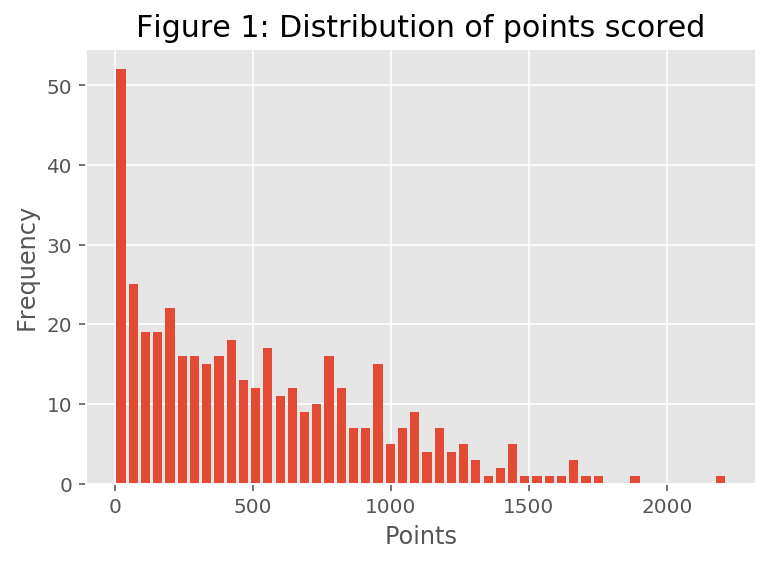

```python
PTS_Dist = dataclean['PTS']

plt.hist(PTS_Dist, bins = 50, rwidth=0.75)
plt.xlabel("Points")
plt.ylabel("Frequency")
plt.title('Figure 1: Distribution of points scored', fontsize = 15)

plt.show();
```

```python
print("The median points scored in a season is" ,dataclean['PTS'].median(), "points")
print("The mean points scored in a season is", dataclean['PTS'].mean(), "points")
```

```
The median points scored in a season is 432.0 points
The mean points scored in a season is 515.8909952606635 points
```

Next, to analyse the distribution of points in more depth, we will look at the box plot. Because of the distribution of data points, i.e. the skewness of the histrogram, a box plot will give us an idea of the dispersion of points in this set of data. Because of this robust nature of the box plot, being able to deal with the skewness of data whilst extracting meaningful information, it should provide us with more insight as to how the points scored is spread.

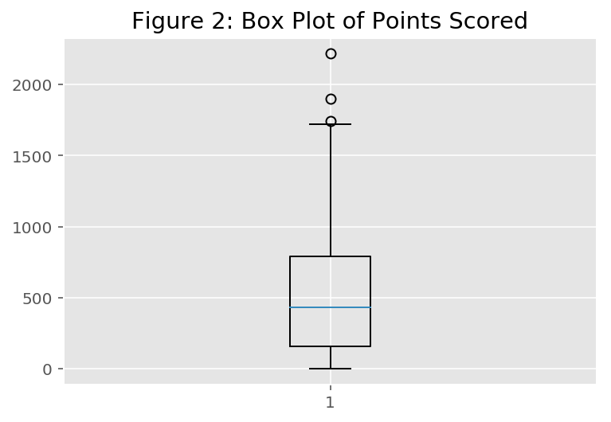

```
The critical values of the box plot includes the following points of interest:
the minimum points scored is 0 points
the 25th percentile of points scored is 154.25 points
the 50th percentile of points scored is 432.0 points
the 75th percentile of points scored is 788.75 points
the maximum points scored is 2217 points

Now, we can determine the interquartile range 634.5
```

```python
plt.boxplot(x = PTS_Dist)
plt.title('Figure 2: Box Plot of Points Scored')
plt.show()

print('The critical values of the box plot includes the following points of interest:')
print("the minimum points scored is",PTS_Dist.min(), "points")
print('the 25th percentile of points scored is',np.quantile(PTS_Dist, 0.25),'points')
print('the 50th percentile of points scored is',np.quantile(PTS_Dist, 0.5),'points')
print('the 75th percentile of points scored is',np.quantile(PTS_Dist, 0.75),'points')
print("the maximum points scored is",PTS_Dist.max(), "points\n")

IQR = np.quantile(PTS_Dist, 0.75)-np.quantile(PTS_Dist, 0.25)
print("Now, we can determine the interquartile range", IQR)
```

## Bivariate Visualisation

The first bivariate plot visualisation is the of total minutes played against points. It will be a scatter plot to analyse and look at the trend of a player's points based on the number of minutes they have played in NBA.

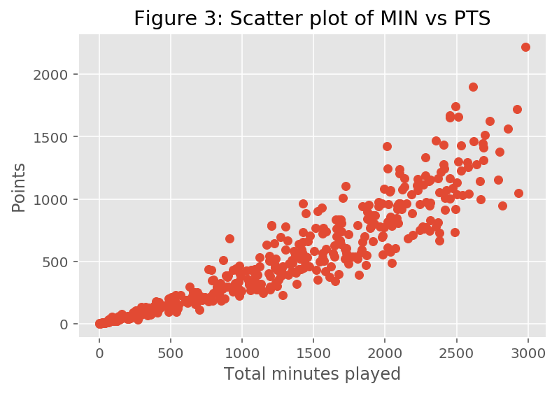

```python
plt.xlabel("Total minutes played")
plt.ylabel("Points")
plt.title("Figure 3: Scatter plot of MIN vs PTS")
scatter = plt.scatter(dataclean['MIN'],dataclean['PTS']);
```

Based the scatter plot above, majority of the players follow a linear pattern as the total minutes played increases. From this data we can form a hypothesis indicating that a majority of player's future result in one game will not be much different from their previous results. The outliers on this scatter plot also follow a slightly linear pattern just above or below the linear pattern of the average player. This also means that it is possible to predict the future score of outlier players.

Next we try to analyse a player's age against their total points. We suspect a peak of points at the prime age of players.

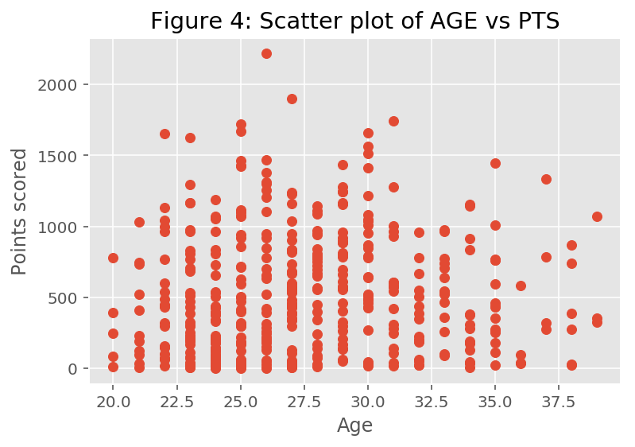

```python
plt.xlabel("Age")
plt.ylabel("Points scored")
plt.title("Figure 4: Scatter plot of AGE vs PTS")
scatter = plt.scatter(dataclean['Age'],dataclean['PTS']);
```

The data points are scattered fairly evenly throughout the above scatter plot. There also seems to be a concentration of players in the middle age ranges. A player's age does not provide any useful measures for the points that they are expected to score.

```python
print('Youngest player: ',dataclean['Age'].min())
print('Oldest player: ',dataclean['Age'].max())
```

```
Youngest player:  20.0
Oldest player:  39.0
```

```python
age20 = dataclean[dataclean['Age'] == 20]
age21 = dataclean[dataclean['Age'] == 21]
age22 = dataclean[dataclean['Age'] == 22]
age23 = dataclean[dataclean['Age'] == 23]
age24 = dataclean[dataclean['Age'] == 24]
age25 = dataclean[dataclean['Age'] == 25]
age26 = dataclean[dataclean['Age'] == 26]
age27 = dataclean[dataclean['Age'] == 27]
age28 = dataclean[dataclean['Age'] == 28]
age29 = dataclean[dataclean['Age'] == 29]
age30 = dataclean[dataclean['Age'] == 30]
age31 = dataclean[dataclean['Age'] == 31]
age32 = dataclean[dataclean['Age'] == 32]
age33 = dataclean[dataclean['Age'] == 33]
age34 = dataclean[dataclean['Age'] == 34]
age35 = dataclean[dataclean['Age'] == 35]
age36 = dataclean[dataclean['Age'] == 36]
age37 = dataclean[dataclean['Age'] == 37]
age38 = dataclean[dataclean['Age'] == 38]
age39 = dataclean[dataclean['Age'] == 39]
```

```python
average20 = age20['PTS'].mean()
average21 = age21['PTS'].mean()
average22 = age22['PTS'].mean()
average23 = age23['PTS'].mean()
average24 = age24['PTS'].mean()
average25 = age25['PTS'].mean()
average26 = age26['PTS'].mean()
average27 = age27['PTS'].mean()
average28 = age28['PTS'].mean()
average29 = age29['PTS'].mean()
average30 = age30['PTS'].mean()
average31 = age31['PTS'].mean()
average32 = age32['PTS'].mean()
average33 = age33['PTS'].mean()
average34 = age34['PTS'].mean()
average35 = age35['PTS'].mean()
average36 = age36['PTS'].mean()
average37 = age37['PTS'].mean()
average38 = age38['PTS'].mean()
average39 = age39['PTS'].mean()
```

```python
xline = [20, 21, 22, 23, 24, 25, 26, 27, 28, 29, 30, 31, 32, 33, 34, 35, 36, 37, 38, 39]
yline = [average20, average21, average22, average23, average24, average25, average26, average27, average28, average29, average30, average31, average32, average33, average34, average35, average36, average37, average38, average39]
```

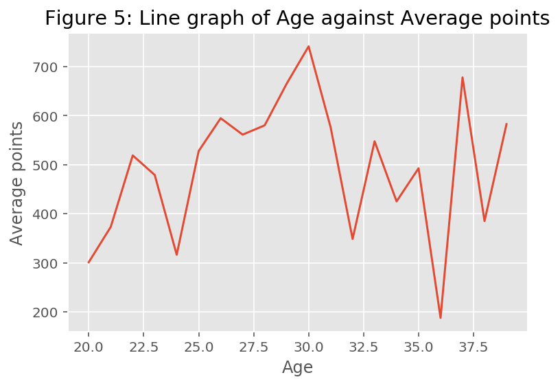

```python
plt.plot(xline, yline);
plt.title('Figure 5: Line graph of Age against Average points')
plt.xlabel('Age')
plt.ylabel('Average points')
plt.show()
```

There are multiple peaks and troughs corresponding to the average points per age range. However, there does not seem to be any indicative evidence that shows that the points a player scores on average is correlated to their maturity.

## Multivariate Visualisation

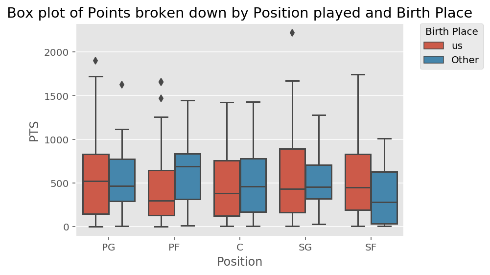

```python
bp=sns.boxplot(x="Pos",
               y="PTS",
               hue="Birth_Place",
               data=dataclean);
plt.title("Box plot of Points broken down by Position played and Birth Place")

# position the legend outside the chart
bp.legend(bbox_to_anchor=(1.05, 1),loc=2, borderaxespad=0.,
          title="Birth Place");

# set the x-axis title
bp.set_xlabel("Position");
```

For NBA players playing the position of PG, C and SG, they seem quite uniform in that players born outside of the US can score just as many points as players playing those positions that were born in the US.

There are two box plots of interest: The first being the position of PF where players born outside the US score a bit more when juxtaposed to players born in the US. Conversely, players who were born in the US and played the SF position scored more than their counterparts born outside of the States.

Despite these differences, the main feature which is points a player scores in fairly uniform between all of these positions which suggests that regardless of a position that a player plays, they still have opportunities to score the ball.

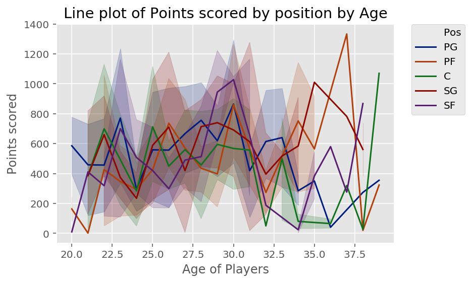

```python
lp = sns.lineplot(x="Age",
                  y="PTS",
                  hue="Pos",
                  palette=sns.color_palette('dark', n_colors=5),
                  data=dataclean);

# position the legend outside the chart
lp.legend(bbox_to_anchor=(1.05, 1),
          loc=2,
          borderaxespad=0.0);

# add a title and axes labels
lp.set(title='Line plot of Points scored by position by Age',
       xlabel='Age of Players',
       ylabel='Points scored');
```

All the line plots show a similar pattern where a player who reaches their mid career, say somewhere near 30 years old, will generally score more points than the average in terms of the position that they play.

We also observe that for 3 postions: PF, SG and C, they score the most points when they are near the end of their career compared to other players playing the same position.

Conversely, for players playing the positions of SF and PG, the points they score are generally lower than the other age ranges in their position.

There are several possible explanations for these trends. One is that the positions of SF and PG are more physically demanding than the other roles, where younger players are more quick and agile. Another possible explanation could be due to injuries which is associated with aging.

```python
data.columns = [colname.replace(' ', '_') for colname in list(data.columns)]
data.columns = [colname.replace('/', '_') for colname in list(data.columns)]
data.columns = [colname.replace('3', 'Three') for colname in list(data.columns)]
data.columns = [colname.replace('%', 'P') for colname in list(data.columns)]
data.head()
```

|  | Games_Played | MIN | PTS | FGA | FGP | ThreePA | ThreePP | FTA | FTP | OREB | ... | PF | EFF | AST_TOV | STL_TOV | Age | Birth_Place | Height | Pos | Weight | BMI |
| --- | --- | --- | --- | --- | --- | --- | --- | --- | --- | --- | --- | --- | --- | --- | --- | --- | --- | --- | --- | --- | --- |
| 0 | 26 | 324 | 133 | 137 | 37.2 | 57 | 26.3 | 24 | 66.7 | 6 | ... | 15 | 110 | 3.29 | 0.50 | 29.0 | us | 185.0 | PG | 81.45 | 23.798393 |
| 1 | 82 | 1885 | 954 | 817 | 42.1 | 313 | 38.7 | 174 | 83.3 | 32 | ... | 189 | 791 | 1.66 | 0.34 | 30.0 | us | 180.0 | PG | 72.45 | 22.361111 |
| 2 | 47 | 797 | 243 | 208 | 44.7 | 48 | 27.1 | 61 | 72.1 | 46 | ... | 83 | 318 | 0.87 | 0.55 | 20.0 | us | 202.5 | PF | 99.00 | 24.142661 |
| 3 | 32 | 740 | 213 | 220 | 41.4 | 9 | 11.1 | 46 | 65.2 | 48 | ... | 88 | 244 | 0.68 | 0.43 | 24.0 | us | 205.0 | PF | 106.65 | 25.377751 |
| 4 | 76 | 2318 | 1156 | 965 | 53.8 | 36 | 30.6 | 141 | 75.9 | 131 | ... | 121 | 1530 | 2.44 | 0.68 | 29.0 | Other | 205.0 | C | 110.25 | 26.234384 |

5 rows × 26 columns

```python
regression = data
regression.head
```

[output not shown]

[output cut: 175 more lines]

```python
data_encoded = pd.get_dummies(regression, drop_first=True)
data_encoded.head()
```

|  | Games_Played | MIN | PTS | FGA | FGP | ThreePA | ThreePP | FTA | FTP | OREB | ... | STL_TOV | Age | Height | Weight | BMI | Birth_Place_us | Pos_PF | Pos_PG | Pos_SF | Pos_SG |
| --- | --- | --- | --- | --- | --- | --- | --- | --- | --- | --- | --- | --- | --- | --- | --- | --- | --- | --- | --- | --- | --- |
| 0 | 26 | 324 | 133 | 137 | 37.2 | 57 | 26.3 | 24 | 66.7 | 6 | ... | 0.50 | 29.0 | 185.0 | 81.45 | 23.798393 | 1 | 0 | 1 | 0 | 0 |
| 1 | 82 | 1885 | 954 | 817 | 42.1 | 313 | 38.7 | 174 | 83.3 | 32 | ... | 0.34 | 30.0 | 180.0 | 72.45 | 22.361111 | 1 | 0 | 1 | 0 | 0 |
| 2 | 47 | 797 | 243 | 208 | 44.7 | 48 | 27.1 | 61 | 72.1 | 46 | ... | 0.55 | 20.0 | 202.5 | 99.00 | 24.142661 | 1 | 1 | 0 | 0 | 0 |
| 3 | 32 | 740 | 213 | 220 | 41.4 | 9 | 11.1 | 46 | 65.2 | 48 | ... | 0.43 | 24.0 | 205.0 | 106.65 | 25.377751 | 1 | 1 | 0 | 0 | 0 |
| 4 | 76 | 2318 | 1156 | 965 | 53.8 | 36 | 30.6 | 141 | 75.9 | 131 | ... | 0.68 | 29.0 | 205.0 | 110.25 | 26.234384 | 0 | 0 | 0 | 0 | 0 |

5 rows × 29 columns

```python
formula_string_indep_vars_encoded = ' + '.join(data_encoded.drop(columns='PTS').columns)
formula_string_encoded = 'PTS ~ ' + formula_string_indep_vars_encoded
print('formula_string_encoded: ', formula_string_encoded)
```

```
formula_string_encoded:  PTS ~ Games_Played + MIN + FGA + FGP + ThreePA + ThreePP + FTA + FTP + OREB + DREB + REB + AST + STL + BLK + TOV + PF + EFF + AST_TOV + STL_TOV + Age + Height + Weight + BMI + Birth_Place_us + Pos_PF + Pos_PG + Pos_SF + Pos_SG
```

## Feature Selection

The below shows our regressional table with all our variables included in the plot. We will employ backward selection to remove variables with p-values greater than a 0.05 significance level and retrieve a new regressional formula for each iteration.

```python
formula_string_indep_vars_encoded = ' + '.join(data_encoded.drop(columns='PTS').columns)
formula_string_encoded = 'PTS ~ ' + formula_string_indep_vars_encoded
print('formula_string_encoded: ', formula_string_encoded)
model_full = sm.formula.ols(formula=formula_string_encoded, data=data_encoded)
###
model_full_fitted = model_full.fit()
###
print(model_full_fitted.summary())
```

```
formula_string_encoded:  PTS ~ Games_Played + MIN + FGA + FGP + ThreePA + ThreePP + FTA + FTP + OREB + DREB + REB + AST + STL + BLK + TOV + PF + EFF + AST_TOV + STL_TOV + Age + Height + Weight + BMI + Birth_Place_us + Pos_PF + Pos_PG + Pos_SF + Pos_SG
                            OLS Regression Results
==============================================================================
Dep. Variable:                    PTS   R-squared:                       1.000
Model:                            OLS   Adj. R-squared:                  1.000
Method:                 Least Squares   F-statistic:                 1.441e+05
Date:                Sun, 27 Oct 2019   Prob (F-statistic):               0.00
Time:                        16:07:15   Log-Likelihood:                -1212.8
No. Observations:                 422   AIC:                             2482.
Df Residuals:                     394   BIC:                             2595.
Df Model:                          27
Covariance Type:            nonrobust
==================================================================================
                     coef    std err          t      P>|t|      [0.025      0.975]
----------------------------------------------------------------------------------
Intercept          0.8244     70.669      0.012      0.991    -138.112     139.761
Games_Played      -0.0466      0.024     -1.954      0.051      -0.093       0.000
MIN                0.0024      0.001      1.626      0.105      -0.000       0.005
FGA                0.6568      0.003    211.072      0.000       0.651       0.663
FGP                0.1524      0.033      4.587      0.000       0.087       0.218
ThreePA            0.1277      0.003     36.859      0.000       0.121       0.135
ThreePP            0.0524      0.020      2.657      0.008       0.014       0.091
FTA                0.4099      0.005     79.167      0.000       0.400       0.420
FTP               -0.0939      0.014     -6.790      0.000      -0.121      -0.067
OREB              -0.1855      0.008    -24.596      0.000      -0.200      -0.171
DREB              -0.2315      0.006    -39.005      0.000      -0.243      -0.220
REB               -0.4170      0.004   -106.513      0.000      -0.425      -0.409
AST               -0.6512      0.007    -90.021      0.000      -0.665      -0.637
STL               -0.6587      0.018    -37.378      0.000      -0.693      -0.624
BLK               -0.6489      0.014    -48.011      0.000      -0.676      -0.622
TOV                0.6430      0.017     38.457      0.000       0.610       0.676
PF                 0.0129      0.010      1.304      0.193      -0.007       0.032
EFF                0.6571      0.004    167.382      0.000       0.649       0.665
AST_TOV           -0.6467      0.460     -1.405      0.161      -1.551       0.258
STL_TOV            0.7609      0.849      0.896      0.371      -0.909       2.431
Age                0.0291      0.056      0.517      0.606      -0.082       0.140
Height            -0.0355      0.354     -0.100      0.920      -0.731       0.660
Weight             0.0182      0.347      0.052      0.958      -0.664       0.701
BMI                0.0579      1.384      0.042      0.967      -2.663       2.778
Birth_Place_us     0.5599      0.570      0.982      0.327      -0.561       1.680
Pos_PF            -0.1588      0.865     -0.184      0.854      -1.858       1.541
Pos_PG             1.5718      1.840      0.854      0.393      -2.045       5.189
Pos_SF             0.6418      1.200      0.535      0.593      -1.717       3.001
Pos_SG             1.8263      1.433      1.275      0.203      -0.990       4.643
==============================================================================
Omnibus:                      142.463   Durbin-Watson:                   2.054
Prob(Omnibus):                  0.000   Jarque-Bera (JB):              838.821
Skew:                           1.315   Prob(JB):                    7.12e-183
Kurtosis:                       9.386   Cond. No.                     1.20e+16
==============================================================================

Warnings:
[1] Standard Errors assume that the covariance matrix of the errors is correctly specified.
[2] The smallest eigenvalue is 9.59e-24. This might indicate that there are
strong multicollinearity problems or that the design matrix is singular.
```

##### Removing BMI

```python
data_encoded = data_encoded.drop(columns='BMI')
formula_string_indep_vars_encoded = ' + '.join(data_encoded.drop(columns='PTS').columns)
formula_string_encoded = 'PTS ~ ' + formula_string_indep_vars_encoded
print('formula_string_encoded: ', formula_string_encoded)
model_full = sm.formula.ols(formula=formula_string_encoded, data=data_encoded)
###
model_full_fitted = model_full.fit()
###
print(model_full_fitted.summary())
```

```
formula_string_encoded:  PTS ~ Games_Played + MIN + FGA + FGP + ThreePA + ThreePP + FTA + FTP + OREB + DREB + REB + AST + STL + BLK + TOV + PF + EFF + AST_TOV + STL_TOV + Age + Height + Weight + Birth_Place_us + Pos_PF + Pos_PG + Pos_SF + Pos_SG
                            OLS Regression Results
==============================================================================
Dep. Variable:                    PTS   R-squared:                       1.000
Model:                            OLS   Adj. R-squared:                  1.000
Method:                 Least Squares   F-statistic:                 1.500e+05
Date:                Sun, 27 Oct 2019   Prob (F-statistic):               0.00
Time:                        16:07:15   Log-Likelihood:                -1212.8
No. Observations:                 422   AIC:                             2480.
Df Residuals:                     395   BIC:                             2589.
Df Model:                          26
Covariance Type:            nonrobust
==================================================================================
                     coef    std err          t      P>|t|      [0.025      0.975]
----------------------------------------------------------------------------------
Intercept          3.7291     13.134      0.284      0.777     -22.093      29.551
Games_Played      -0.0466      0.024     -1.956      0.051      -0.093       0.000
MIN                0.0024      0.001      1.630      0.104      -0.000       0.005
FGA                0.6568      0.003    211.803      0.000       0.651       0.663
FGP                0.1523      0.033      4.598      0.000       0.087       0.217
ThreePA            0.1277      0.003     36.977      0.000       0.121       0.135
ThreePP            0.0523      0.020      2.660      0.008       0.014       0.091
FTA                0.4099      0.005     79.332      0.000       0.400       0.420
FTP               -0.0938      0.014     -6.806      0.000      -0.121      -0.067
OREB              -0.1855      0.008    -24.628      0.000      -0.200      -0.171
DREB              -0.2315      0.006    -39.054      0.000      -0.243      -0.220
REB               -0.4170      0.004   -106.690      0.000      -0.425      -0.409
AST               -0.6512      0.007    -90.369      0.000      -0.665      -0.637
STL               -0.6587      0.018    -37.517      0.000      -0.693      -0.624
BLK               -0.6489      0.013    -48.072      0.000      -0.675      -0.622
TOV                0.6430      0.017     38.510      0.000       0.610       0.676
PF                 0.0129      0.010      1.307      0.192      -0.007       0.032
EFF                0.6571      0.004    167.658      0.000       0.649       0.665
AST_TOV           -0.6470      0.460     -1.408      0.160      -1.550       0.257
STL_TOV            0.7638      0.845      0.903      0.367      -0.898       2.426
Age                0.0291      0.056      0.517      0.605      -0.082       0.140
Height            -0.0501      0.066     -0.764      0.445      -0.179       0.079
Weight             0.0326      0.039      0.831      0.407      -0.045       0.110
Birth_Place_us     0.5605      0.569      0.985      0.325      -0.558       1.679
Pos_PF            -0.1535      0.854     -0.180      0.857      -1.833       1.526
Pos_PG             1.5646      1.829      0.855      0.393      -2.032       5.161
Pos_SF             0.6484      1.188      0.546      0.586      -1.687       2.984
Pos_SG             1.8291      1.429      1.280      0.201      -0.981       4.639
==============================================================================
Omnibus:                      142.331   Durbin-Watson:                   2.054
Prob(Omnibus):                  0.000   Jarque-Bera (JB):              837.221
Skew:                           1.314   Prob(JB):                    1.58e-182
Kurtosis:                       9.380   Cond. No.                     1.20e+16
==============================================================================

Warnings:
[1] Standard Errors assume that the covariance matrix of the errors is correctly specified.
[2] The smallest eigenvalue is 9.59e-24. This might indicate that there are
strong multicollinearity problems or that the design matrix is singular.
```

##### Removing Pos_PF

```python
data_encoded = data_encoded.drop(columns='Pos_PF')
formula_string_indep_vars_encoded = ' + '.join(data_encoded.drop(columns='PTS').columns)
formula_string_encoded = 'PTS ~ ' + formula_string_indep_vars_encoded
print('formula_string_encoded: ', formula_string_encoded)
model_full = sm.formula.ols(formula=formula_string_encoded, data=data_encoded)
###
model_full_fitted = model_full.fit()
###
print(model_full_fitted.summary())
```

```
formula_string_encoded:  PTS ~ Games_Played + MIN + FGA + FGP + ThreePA + ThreePP + FTA + FTP + OREB + DREB + REB + AST + STL + BLK + TOV + PF + EFF + AST_TOV + STL_TOV + Age + Height + Weight + Birth_Place_us + Pos_PG + Pos_SF + Pos_SG
                            OLS Regression Results
==============================================================================
Dep. Variable:                    PTS   R-squared:                       1.000
Model:                            OLS   Adj. R-squared:                  1.000
Method:                 Least Squares   F-statistic:                 1.564e+05
Date:                Sun, 27 Oct 2019   Prob (F-statistic):               0.00
Time:                        16:07:15   Log-Likelihood:                -1212.8
No. Observations:                 422   AIC:                             2478.
Df Residuals:                     396   BIC:                             2583.
Df Model:                          25
Covariance Type:            nonrobust
==================================================================================
                     coef    std err          t      P>|t|      [0.025      0.975]
----------------------------------------------------------------------------------
Intercept          3.0338     12.536      0.242      0.809     -21.613      27.680
Games_Played      -0.0468      0.024     -1.973      0.049      -0.094      -0.000
MIN                0.0024      0.001      1.631      0.104      -0.000       0.005
FGA                0.6568      0.003    212.152      0.000       0.651       0.663
FGP                0.1535      0.032      4.737      0.000       0.090       0.217
ThreePA            0.1277      0.003     37.037      0.000       0.121       0.135
ThreePP            0.0517      0.019      2.673      0.008       0.014       0.090
FTA                0.4098      0.005     79.644      0.000       0.400       0.420
FTP               -0.0938      0.014     -6.812      0.000      -0.121      -0.067
OREB              -0.1853      0.007    -24.828      0.000      -0.200      -0.171
DREB              -0.2316      0.006    -39.381      0.000      -0.243      -0.220
REB               -0.4169      0.004   -107.038      0.000      -0.425      -0.409
AST               -0.6512      0.007    -90.482      0.000      -0.665      -0.637
STL               -0.6587      0.018    -37.563      0.000      -0.693      -0.624
BLK               -0.6485      0.013    -48.901      0.000      -0.675      -0.622
TOV                0.6433      0.017     38.709      0.000       0.611       0.676
PF                 0.0129      0.010      1.303      0.193      -0.007       0.032
EFF                0.6571      0.004    167.864      0.000       0.649       0.665
AST_TOV           -0.6485      0.459     -1.413      0.158      -1.551       0.254
STL_TOV            0.7536      0.843      0.894      0.372      -0.903       2.410
Age                0.0301      0.056      0.536      0.592      -0.080       0.140
Height            -0.0478      0.064     -0.744      0.457      -0.174       0.078
Weight             0.0333      0.039      0.854      0.394      -0.043       0.110
Birth_Place_us     0.5466      0.563      0.971      0.332      -0.561       1.654
Pos_PG             1.7503      1.507      1.161      0.246      -1.213       4.714
Pos_SF             0.7928      0.874      0.907      0.365      -0.926       2.511
Pos_SG             1.9966      1.082      1.845      0.066      -0.131       4.124
==============================================================================
Omnibus:                      142.743   Durbin-Watson:                   2.055
Prob(Omnibus):                  0.000   Jarque-Bera (JB):              841.865
Skew:                           1.318   Prob(JB):                    1.55e-183
Kurtosis:                       9.398   Cond. No.                     1.20e+16
==============================================================================

Warnings:
[1] Standard Errors assume that the covariance matrix of the errors is correctly specified.
[2] The smallest eigenvalue is 9.59e-24. This might indicate that there are
strong multicollinearity problems or that the design matrix is singular.
```

##### Removing Age

```python
data_encoded = data_encoded.drop(columns='Age')
formula_string_indep_vars_encoded = ' + '.join(data_encoded.drop(columns='PTS').columns)
formula_string_encoded = 'PTS ~ ' + formula_string_indep_vars_encoded
print('formula_string_encoded: ', formula_string_encoded)
model_full = sm.formula.ols(formula=formula_string_encoded, data=data_encoded)
###
model_full_fitted = model_full.fit()
###
print(model_full_fitted.summary())
```

```
formula_string_encoded:  PTS ~ Games_Played + MIN + FGA + FGP + ThreePA + ThreePP + FTA + FTP + OREB + DREB + REB + AST + STL + BLK + TOV + PF + EFF + AST_TOV + STL_TOV + Height + Weight + Birth_Place_us + Pos_PG + Pos_SF + Pos_SG
                            OLS Regression Results
==============================================================================
Dep. Variable:                    PTS   R-squared:                       1.000
Model:                            OLS   Adj. R-squared:                  1.000
Method:                 Least Squares   F-statistic:                 1.632e+05
Date:                Sun, 27 Oct 2019   Prob (F-statistic):               0.00
Time:                        16:07:15   Log-Likelihood:                -1213.0
No. Observations:                 422   AIC:                             2476.
Df Residuals:                     397   BIC:                             2577.
Df Model:                          24
Covariance Type:            nonrobust
==================================================================================
                     coef    std err          t      P>|t|      [0.025      0.975]
----------------------------------------------------------------------------------
Intercept          4.5078     12.221      0.369      0.712     -19.518      28.533
Games_Played      -0.0458      0.024     -1.937      0.054      -0.092       0.001
MIN                0.0024      0.001      1.646      0.100      -0.000       0.005
FGA                0.6566      0.003    213.827      0.000       0.651       0.663
FGP                0.1533      0.032      4.737      0.000       0.090       0.217
ThreePA            0.1277      0.003     37.070      0.000       0.121       0.135
ThreePP            0.0511      0.019      2.648      0.008       0.013       0.089
FTA                0.4096      0.005     79.884      0.000       0.400       0.420
FTP               -0.0932      0.014     -6.797      0.000      -0.120      -0.066
OREB              -0.1859      0.007    -25.156      0.000      -0.200      -0.171
DREB              -0.2313      0.006    -39.565      0.000      -0.243      -0.220
REB               -0.4171      0.004   -107.815      0.000      -0.425      -0.410
AST               -0.6515      0.007    -90.886      0.000      -0.666      -0.637
STL               -0.6600      0.017    -37.988      0.000      -0.694      -0.626
BLK               -0.6494      0.013    -49.387      0.000      -0.675      -0.624
TOV                0.6440      0.017     38.912      0.000       0.611       0.677
PF                 0.0127      0.010      1.287      0.199      -0.007       0.032
EFF                0.6574      0.004    169.352      0.000       0.650       0.665
AST_TOV           -0.6052      0.451     -1.341      0.181      -1.493       0.282
STL_TOV            0.7571      0.842      0.899      0.369      -0.898       2.412
Height            -0.0525      0.064     -0.826      0.409      -0.177       0.072
Weight             0.0354      0.039      0.914      0.361      -0.041       0.112
Birth_Place_us     0.5543      0.562      0.986      0.325      -0.551       1.660
Pos_PG             1.6347      1.491      1.097      0.273      -1.296       4.565
Pos_SF             0.7674      0.872      0.880      0.379      -0.947       2.482
Pos_SG             1.9269      1.074      1.795      0.073      -0.184       4.037
==============================================================================
Omnibus:                      143.572   Durbin-Watson:                   2.050
Prob(Omnibus):                  0.000   Jarque-Bera (JB):              849.930
Skew:                           1.325   Prob(JB):                    2.75e-185
Kurtosis:                       9.427   Cond. No.                     1.20e+16
==============================================================================

Warnings:
[1] Standard Errors assume that the covariance matrix of the errors is correctly specified.
[2] The smallest eigenvalue is 9.58e-24. This might indicate that there are
strong multicollinearity problems or that the design matrix is singular.
```

##### Removing Height

```python
data_encoded = data_encoded.drop(columns='Height')
formula_string_indep_vars_encoded = ' + '.join(data_encoded.drop(columns='PTS').columns)
formula_string_encoded = 'PTS ~ ' + formula_string_indep_vars_encoded
print('formula_string_encoded: ', formula_string_encoded)
model_full = sm.formula.ols(formula=formula_string_encoded, data=data_encoded)
###
model_full_fitted = model_full.fit()
###
print(model_full_fitted.summary())
```

```
formula_string_encoded:  PTS ~ Games_Played + MIN + FGA + FGP + ThreePA + ThreePP + FTA + FTP + OREB + DREB + REB + AST + STL + BLK + TOV + PF + EFF + AST_TOV + STL_TOV + Weight + Birth_Place_us + Pos_PG + Pos_SF + Pos_SG
                            OLS Regression Results
==============================================================================
Dep. Variable:                    PTS   R-squared:                       1.000
Model:                            OLS   Adj. R-squared:                  1.000
Method:                 Least Squares   F-statistic:                 1.704e+05
Date:                Sun, 27 Oct 2019   Prob (F-statistic):               0.00
Time:                        16:07:15   Log-Likelihood:                -1213.3
No. Observations:                 422   AIC:                             2475.
Df Residuals:                     398   BIC:                             2572.
Df Model:                          23
Covariance Type:            nonrobust
==================================================================================
                     coef    std err          t      P>|t|      [0.025      0.975]
----------------------------------------------------------------------------------
Intercept         -4.9516      4.265     -1.161      0.246     -13.336       3.433
Games_Played      -0.0451      0.024     -1.911      0.057      -0.092       0.001
MIN                0.0024      0.001      1.628      0.104      -0.000       0.005
FGA                0.6567      0.003    214.577      0.000       0.651       0.663
FGP                0.1524      0.032      4.713      0.000       0.089       0.216
ThreePA            0.1277      0.003     37.090      0.000       0.121       0.135
ThreePP            0.0506      0.019      2.625      0.009       0.013       0.089
FTA                0.4099      0.005     80.111      0.000       0.400       0.420
FTP               -0.0942      0.014     -6.899      0.000      -0.121      -0.067
OREB              -0.1854      0.007    -25.179      0.000      -0.200      -0.171
DREB              -0.2317      0.006    -39.775      0.000      -0.243      -0.220
REB               -0.4171      0.004   -107.881      0.000      -0.425      -0.409
AST               -0.6510      0.007    -91.164      0.000      -0.665      -0.637
STL               -0.6601      0.017    -38.014      0.000      -0.694      -0.626
BLK               -0.6508      0.013    -49.930      0.000      -0.676      -0.625
TOV                0.6426      0.016     39.057      0.000       0.610       0.675
PF                 0.0129      0.010      1.312      0.190      -0.006       0.032
EFF                0.6574      0.004    169.420      0.000       0.650       0.665
AST_TOV           -0.6051      0.451     -1.341      0.181      -1.492       0.282
STL_TOV            0.8207      0.838      0.980      0.328      -0.827       2.468
Weight             0.0239      0.036      0.661      0.509      -0.047       0.095
Birth_Place_us     0.6398      0.553      1.158      0.248      -0.447       1.726
Pos_PG             2.3001      1.254      1.835      0.067      -0.164       4.765
Pos_SF             0.8669      0.863      1.004      0.316      -0.830       2.564
Pos_SG             2.3155      0.965      2.400      0.017       0.419       4.212
==============================================================================
Omnibus:                      142.998   Durbin-Watson:                   2.044
Prob(Omnibus):                  0.000   Jarque-Bera (JB):              854.002
Skew:                           1.316   Prob(JB):                    3.60e-186
Kurtosis:                       9.453   Cond. No.                     4.15e+16
==============================================================================

Warnings:
[1] Standard Errors assume that the covariance matrix of the errors is correctly specified.
[2] The smallest eigenvalue is 8.01e-25. This might indicate that there are
strong multicollinearity problems or that the design matrix is singular.
```

##### Removing Weight

```python
data_encoded = data_encoded.drop(columns='Weight')
formula_string_indep_vars_encoded = ' + '.join(data_encoded.drop(columns='PTS').columns)
formula_string_encoded = 'PTS ~ ' + formula_string_indep_vars_encoded
print('formula_string_encoded: ', formula_string_encoded)
model_full = sm.formula.ols(formula=formula_string_encoded, data=data_encoded)
###
model_full_fitted = model_full.fit()
###
print(model_full_fitted.summary())
```

```
formula_string_encoded:  PTS ~ Games_Played + MIN + FGA + FGP + ThreePA + ThreePP + FTA + FTP + OREB + DREB + REB + AST + STL + BLK + TOV + PF + EFF + AST_TOV + STL_TOV + Birth_Place_us + Pos_PG + Pos_SF + Pos_SG
                            OLS Regression Results
==============================================================================
Dep. Variable:                    PTS   R-squared:                       1.000
Model:                            OLS   Adj. R-squared:                  1.000
Method:                 Least Squares   F-statistic:                 2.134e+05
Date:                Sun, 27 Oct 2019   Prob (F-statistic):               0.00
Time:                        16:07:15   Log-Likelihood:                -1399.0
No. Observations:                 490   AIC:                             2844.
Df Residuals:                     467   BIC:                             2941.
Df Model:                          22
Covariance Type:            nonrobust
==================================================================================
                     coef    std err          t      P>|t|      [0.025      0.975]
----------------------------------------------------------------------------------
Intercept         -0.9852      1.290     -0.763      0.446      -3.521       1.551
Games_Played      -0.0369      0.021     -1.768      0.078      -0.078       0.004
MIN                0.0024      0.001      1.902      0.058   -8.09e-05       0.005
FGA                0.6592      0.003    239.295      0.000       0.654       0.665
FGP                0.1426      0.026      5.399      0.000       0.091       0.195
ThreePA            0.1283      0.003     41.081      0.000       0.122       0.134
ThreePP            0.0505      0.016      3.132      0.002       0.019       0.082
FTA                0.4090      0.005     87.259      0.000       0.400       0.418
FTP               -0.0951      0.012     -7.796      0.000      -0.119      -0.071
OREB              -0.1844      0.007    -27.229      0.000      -0.198      -0.171
DREB              -0.2324      0.005    -43.729      0.000      -0.243      -0.222
REB               -0.4169      0.004   -117.229      0.000      -0.424      -0.410
AST               -0.6528      0.006   -101.644      0.000      -0.665      -0.640
STL               -0.6488      0.016    -41.228      0.000      -0.680      -0.618
BLK               -0.6357      0.012    -53.712      0.000      -0.659      -0.612
TOV                0.6524      0.015     43.129      0.000       0.623       0.682
PF                 0.0038      0.009      0.434      0.664      -0.013       0.021
EFF                0.6543      0.003    190.251      0.000       0.647       0.661
AST_TOV           -0.4133      0.383     -1.079      0.281      -1.166       0.339
STL_TOV            0.6039      0.759      0.796      0.426      -0.887       2.095
Birth_Place_us     0.1232      0.466      0.264      0.792      -0.793       1.039
Pos_PG             0.8048      0.811      0.992      0.322      -0.789       2.399
Pos_SF            -0.1095      0.699     -0.157      0.876      -1.483       1.264
Pos_SG             1.0210      0.676      1.511      0.131      -0.307       2.349
==============================================================================
Omnibus:                      181.718   Durbin-Watson:                   2.008
Prob(Omnibus):                  0.000   Jarque-Bera (JB):             1339.898
Skew:                           1.417   Prob(JB):                    1.11e-291
Kurtosis:                      10.590   Cond. No.                     3.90e+16
==============================================================================

Warnings:
[1] Standard Errors assume that the covariance matrix of the errors is correctly specified.
[2] The smallest eigenvalue is 1.01e-24. This might indicate that there are
strong multicollinearity problems or that the design matrix is singular.
```

##### Removing Pos_SF

```python
data_encoded = data_encoded.drop(columns='Pos_SF')
formula_string_indep_vars_encoded = ' + '.join(data_encoded.drop(columns='PTS').columns)
formula_string_encoded = 'PTS ~ ' + formula_string_indep_vars_encoded
print('formula_string_encoded: ', formula_string_encoded)
model_full = sm.formula.ols(formula=formula_string_encoded, data=data_encoded)
###
model_full_fitted = model_full.fit()
###
print(model_full_fitted.summary())
```

```
formula_string_encoded:  PTS ~ Games_Played + MIN + FGA + FGP + ThreePA + ThreePP + FTA + FTP + OREB + DREB + REB + AST + STL + BLK + TOV + PF + EFF + AST_TOV + STL_TOV + Birth_Place_us + Pos_PG + Pos_SG
                            OLS Regression Results
==============================================================================
Dep. Variable:                    PTS   R-squared:                       1.000
Model:                            OLS   Adj. R-squared:                  1.000
Method:                 Least Squares   F-statistic:                 2.241e+05
Date:                Sun, 27 Oct 2019   Prob (F-statistic):               0.00
Time:                        16:07:15   Log-Likelihood:                -1399.0
No. Observations:                 490   AIC:                             2842.
Df Residuals:                     468   BIC:                             2934.
Df Model:                          21
Covariance Type:            nonrobust
==================================================================================
                     coef    std err          t      P>|t|      [0.025      0.975]
----------------------------------------------------------------------------------
Intercept         -1.0155      1.275     -0.797      0.426      -3.520       1.489
Games_Played      -0.0370      0.021     -1.771      0.077      -0.078       0.004
MIN                0.0024      0.001      1.915      0.056   -6.18e-05       0.005
FGA                0.6593      0.003    243.652      0.000       0.654       0.665
FGP                0.1432      0.026      5.485      0.000       0.092       0.195
ThreePA            0.1283      0.003     41.198      0.000       0.122       0.134
ThreePP            0.0500      0.016      3.166      0.002       0.019       0.081
FTA                0.4090      0.005     87.352      0.000       0.400       0.418
FTP               -0.0950      0.012     -7.803      0.000      -0.119      -0.071
OREB              -0.1843      0.007    -27.336      0.000      -0.198      -0.171
DREB              -0.2324      0.005    -43.784      0.000      -0.243      -0.222
REB               -0.4168      0.004   -118.335      0.000      -0.424      -0.410
AST               -0.6527      0.006   -102.536      0.000      -0.665      -0.640
STL               -0.6488      0.016    -41.279      0.000      -0.680      -0.618
BLK               -0.6356      0.012    -53.841      0.000      -0.659      -0.612
TOV                0.6521      0.015     43.459      0.000       0.623       0.682
PF                 0.0040      0.009      0.470      0.638      -0.013       0.021
EFF                0.6542      0.003    190.774      0.000       0.647       0.661
AST_TOV           -0.4141      0.383     -1.082      0.280      -1.166       0.338
STL_TOV            0.5917      0.754      0.785      0.433      -0.890       2.073
Birth_Place_us     0.1041      0.450      0.232      0.817      -0.779       0.987
Pos_PG             0.8520      0.752      1.133      0.258      -0.626       2.330
Pos_SG             1.0747      0.582      1.847      0.065      -0.069       2.218
==============================================================================
Omnibus:                      181.421   Durbin-Watson:                   2.009
Prob(Omnibus):                  0.000   Jarque-Bera (JB):             1335.572
Skew:                           1.414   Prob(JB):                    9.64e-291
Kurtosis:                      10.577   Cond. No.                     3.93e+16
==============================================================================

Warnings:
[1] Standard Errors assume that the covariance matrix of the errors is correctly specified.
[2] The smallest eigenvalue is 9.95e-25. This might indicate that there are
strong multicollinearity problems or that the design matrix is singular.
```

##### Removing Birth_Place_Us

```python
data_encoded = data_encoded.drop(columns='Birth_Place_us')
formula_string_indep_vars_encoded = ' + '.join(data_encoded.drop(columns='PTS').columns)
formula_string_encoded = 'PTS ~ ' + formula_string_indep_vars_encoded
print('formula_string_encoded: ', formula_string_encoded)
model_full = sm.formula.ols(formula=formula_string_encoded, data=data_encoded)
###
model_full_fitted = model_full.fit()
###
print(model_full_fitted.summary())
```

```
formula_string_encoded:  PTS ~ Games_Played + MIN + FGA + FGP + ThreePA + ThreePP + FTA + FTP + OREB + DREB + REB + AST + STL + BLK + TOV + PF + EFF + AST_TOV + STL_TOV + Pos_PG + Pos_SG
                            OLS Regression Results
==============================================================================
Dep. Variable:                    PTS   R-squared:                       1.000
Model:                            OLS   Adj. R-squared:                  1.000
Method:                 Least Squares   F-statistic:                 2.358e+05
Date:                Sun, 27 Oct 2019   Prob (F-statistic):               0.00
Time:                        16:07:16   Log-Likelihood:                -1399.1
No. Observations:                 490   AIC:                             2840.
Df Residuals:                     469   BIC:                             2928.
Df Model:                          20
Covariance Type:            nonrobust
================================================================================
                   coef    std err          t      P>|t|      [0.025      0.975]
--------------------------------------------------------------------------------
Intercept       -0.9645      1.254     -0.769      0.442      -3.429       1.500
Games_Played    -0.0372      0.021     -1.784      0.075      -0.078       0.004
MIN              0.0024      0.001      1.915      0.056    -6.2e-05       0.005
FGA              0.6593      0.003    244.199      0.000       0.654       0.665
FGP              0.1435      0.026      5.507      0.000       0.092       0.195
ThreePA          0.1283      0.003     41.326      0.000       0.122       0.134
ThreePP          0.0499      0.016      3.165      0.002       0.019       0.081
FTA              0.4091      0.005     87.732      0.000       0.400       0.418
FTP             -0.0951      0.012     -7.815      0.000      -0.119      -0.071
OREB            -0.1844      0.007    -27.423      0.000      -0.198      -0.171
DREB            -0.2323      0.005    -44.055      0.000      -0.243      -0.222
REB             -0.4167      0.004   -118.595      0.000      -0.424      -0.410
AST             -0.6526      0.006   -102.703      0.000      -0.665      -0.640
STL             -0.6485      0.016    -41.381      0.000      -0.679      -0.618
BLK             -0.6356      0.012    -53.899      0.000      -0.659      -0.612
TOV              0.6517      0.015     43.717      0.000       0.622       0.681
PF               0.0040      0.009      0.474      0.635      -0.013       0.021
EFF              0.6542      0.003    191.453      0.000       0.647       0.661
AST_TOV         -0.4212      0.381     -1.105      0.270      -1.170       0.328
STL_TOV          0.6061      0.750      0.808      0.420      -0.869       2.081
Pos_PG           0.8972      0.726      1.236      0.217      -0.529       2.324
Pos_SG           1.1096      0.561      1.976      0.049       0.006       2.213
==============================================================================
Omnibus:                      181.882   Durbin-Watson:                   2.007
Prob(Omnibus):                  0.000   Jarque-Bera (JB):             1344.783
Skew:                           1.417   Prob(JB):                    9.64e-293
Kurtosis:                      10.605   Cond. No.                     3.92e+16
==============================================================================

Warnings:
[1] Standard Errors assume that the covariance matrix of the errors is correctly specified.
[2] The smallest eigenvalue is 9.99e-25. This might indicate that there are
strong multicollinearity problems or that the design matrix is singular.
```

##### Removing PF

```python
data_encoded = data_encoded.drop(columns='PF')
formula_string_indep_vars_encoded = ' + '.join(data_encoded.drop(columns='PTS').columns)
formula_string_encoded = 'PTS ~ ' + formula_string_indep_vars_encoded
print('formula_string_encoded: ', formula_string_encoded)
model_full = sm.formula.ols(formula=formula_string_encoded, data=data_encoded)
###
model_full_fitted = model_full.fit()
###
print(model_full_fitted.summary())
```

```
formula_string_encoded:  PTS ~ Games_Played + MIN + FGA + FGP + ThreePA + ThreePP + FTA + FTP + OREB + DREB + REB + AST + STL + BLK + TOV + EFF + AST_TOV + STL_TOV + Pos_PG + Pos_SG
                            OLS Regression Results
==============================================================================
Dep. Variable:                    PTS   R-squared:                       1.000
Model:                            OLS   Adj. R-squared:                  1.000
Method:                 Least Squares   F-statistic:                 2.486e+05
Date:                Sun, 27 Oct 2019   Prob (F-statistic):               0.00
Time:                        16:07:16   Log-Likelihood:                -1399.2
No. Observations:                 490   AIC:                             2838.
Df Residuals:                     470   BIC:                             2922.
Df Model:                          19
Covariance Type:            nonrobust
================================================================================
                   coef    std err          t      P>|t|      [0.025      0.975]
--------------------------------------------------------------------------------
Intercept       -0.9645      1.253     -0.770      0.442      -3.427       1.498
Games_Played    -0.0334      0.019     -1.735      0.083      -0.071       0.004
MIN              0.0025      0.001      2.020      0.044    6.72e-05       0.005
FGA              0.6592      0.003    244.541      0.000       0.654       0.665
FGP              0.1437      0.026      5.519      0.000       0.093       0.195
ThreePA          0.1284      0.003     41.552      0.000       0.122       0.135
ThreePP          0.0495      0.016      3.147      0.002       0.019       0.080
FTA              0.4088      0.005     88.429      0.000       0.400       0.418
FTP             -0.0953      0.012     -7.843      0.000      -0.119      -0.071
OREB            -0.1839      0.007    -27.769      0.000      -0.197      -0.171
DREB            -0.2324      0.005    -44.186      0.000      -0.243      -0.222
REB             -0.4163      0.003   -122.222      0.000      -0.423      -0.410
AST             -0.6529      0.006   -103.102      0.000      -0.665      -0.640
STL             -0.6476      0.016    -41.690      0.000      -0.678      -0.617
BLK             -0.6348      0.012    -54.420      0.000      -0.658      -0.612
TOV              0.6534      0.014     45.155      0.000       0.625       0.682
EFF              0.6540      0.003    192.271      0.000       0.647       0.661
AST_TOV         -0.4237      0.381     -1.113      0.266      -1.172       0.324
STL_TOV          0.5913      0.749      0.789      0.430      -0.881       2.063
Pos_PG           0.8983      0.725      1.239      0.216      -0.527       2.323
Pos_SG           1.1093      0.561      1.978      0.049       0.007       2.212
==============================================================================
Omnibus:                      180.155   Durbin-Watson:                   2.006
Prob(Omnibus):                  0.000   Jarque-Bera (JB):             1320.673
Skew:                           1.404   Prob(JB):                    1.66e-287
Kurtosis:                      10.537   Cond. No.                     3.98e+16
==============================================================================

Warnings:
[1] Standard Errors assume that the covariance matrix of the errors is correctly specified.
[2] The smallest eigenvalue is 9.65e-25. This might indicate that there are
strong multicollinearity problems or that the design matrix is singular.
```

##### Removing STL_TOV

```python
data_encoded = data_encoded.drop(columns='STL_TOV')
formula_string_indep_vars_encoded = ' + '.join(data_encoded.drop(columns='PTS').columns)
formula_string_encoded = 'PTS ~ ' + formula_string_indep_vars_encoded
print('formula_string_encoded: ', formula_string_encoded)
model_full = sm.formula.ols(formula=formula_string_encoded, data=data_encoded)
###
model_full_fitted = model_full.fit()
###
print(model_full_fitted.summary())
```

```
formula_string_encoded:  PTS ~ Games_Played + MIN + FGA + FGP + ThreePA + ThreePP + FTA + FTP + OREB + DREB + REB + AST + STL + BLK + TOV + EFF + AST_TOV + Pos_PG + Pos_SG
                            OLS Regression Results
==============================================================================
Dep. Variable:                    PTS   R-squared:                       1.000
Model:                            OLS   Adj. R-squared:                  1.000
Method:                 Least Squares   F-statistic:                 2.626e+05
Date:                Sun, 27 Oct 2019   Prob (F-statistic):               0.00
Time:                        16:07:16   Log-Likelihood:                -1399.5
No. Observations:                 490   AIC:                             2837.
Df Residuals:                     471   BIC:                             2917.
Df Model:                          18
Covariance Type:            nonrobust
================================================================================
                   coef    std err          t      P>|t|      [0.025      0.975]
--------------------------------------------------------------------------------
Intercept       -0.7434      1.221     -0.609      0.543      -3.142       1.656
Games_Played    -0.0320      0.019     -1.667      0.096      -0.070       0.006
MIN              0.0024      0.001      1.955      0.051   -1.17e-05       0.005
FGA              0.6592      0.003    244.706      0.000       0.654       0.664
FGP              0.1421      0.026      5.477      0.000       0.091       0.193
ThreePA          0.1283      0.003     41.574      0.000       0.122       0.134
ThreePP          0.0494      0.016      3.146      0.002       0.019       0.080
FTA              0.4089      0.005     88.523      0.000       0.400       0.418
FTP             -0.0939      0.012     -7.813      0.000      -0.118      -0.070
OREB            -0.1839      0.007    -27.775      0.000      -0.197      -0.171
DREB            -0.2325      0.005    -44.226      0.000      -0.243      -0.222
REB             -0.4164      0.003   -122.295      0.000      -0.423      -0.410
AST             -0.6533      0.006   -103.729      0.000      -0.666      -0.641
STL             -0.6406      0.013    -50.196      0.000      -0.666      -0.616
BLK             -0.6348      0.012    -54.437      0.000      -0.658      -0.612
TOV              0.6509      0.014     46.169      0.000       0.623       0.679
EFF              0.6541      0.003    192.395      0.000       0.647       0.661
AST_TOV         -0.3221      0.358     -0.900      0.369      -1.026       0.382
Pos_PG           0.7789      0.709      1.098      0.273      -0.614       2.172
Pos_SG           1.0938      0.560      1.952      0.052      -0.007       2.195
==============================================================================
Omnibus:                      181.163   Durbin-Watson:                   2.003
Prob(Omnibus):                  0.000   Jarque-Bera (JB):             1338.487
Skew:                           1.411   Prob(JB):                    2.25e-291
Kurtosis:                      10.589   Cond. No.                     4.05e+16
==============================================================================

Warnings:
[1] Standard Errors assume that the covariance matrix of the errors is correctly specified.
[2] The smallest eigenvalue is 9.35e-25. This might indicate that there are
strong multicollinearity problems or that the design matrix is singular.
```

##### Removing AST_TOV

```python
data_encoded = data_encoded.drop(columns='AST_TOV')
formula_string_indep_vars_encoded = ' + '.join(data_encoded.drop(columns='PTS').columns)
formula_string_encoded = 'PTS ~ ' + formula_string_indep_vars_encoded
print('formula_string_encoded: ', formula_string_encoded)
model_full = sm.formula.ols(formula=formula_string_encoded, data=data_encoded)
###
model_full_fitted = model_full.fit()
###
print(model_full_fitted.summary())
```

```
formula_string_encoded:  PTS ~ Games_Played + MIN + FGA + FGP + ThreePA + ThreePP + FTA + FTP + OREB + DREB + REB + AST + STL + BLK + TOV + EFF + Pos_PG + Pos_SG
                            OLS Regression Results
==============================================================================
Dep. Variable:                    PTS   R-squared:                       1.000
Model:                            OLS   Adj. R-squared:                  1.000
Method:                 Least Squares   F-statistic:                 2.782e+05
Date:                Sun, 27 Oct 2019   Prob (F-statistic):               0.00
Time:                        16:07:16   Log-Likelihood:                -1399.9
No. Observations:                 490   AIC:                             2836.
Df Residuals:                     472   BIC:                             2911.
Df Model:                          17
Covariance Type:            nonrobust
================================================================================
                   coef    std err          t      P>|t|      [0.025      0.975]
--------------------------------------------------------------------------------
Intercept       -1.0152      1.183     -0.858      0.391      -3.339       1.309
Games_Played    -0.0337      0.019     -1.771      0.077      -0.071       0.004
MIN              0.0024      0.001      1.956      0.051   -1.06e-05       0.005
FGA              0.6590      0.003    245.590      0.000       0.654       0.664
FGP              0.1430      0.026      5.513      0.000       0.092       0.194
ThreePA          0.1285      0.003     41.717      0.000       0.122       0.135
ThreePP          0.0468      0.015      3.031      0.003       0.016       0.077
FTA              0.4088      0.005     88.575      0.000       0.400       0.418
FTP             -0.0947      0.012     -7.900      0.000      -0.118      -0.071
OREB            -0.1838      0.007    -27.775      0.000      -0.197      -0.171
DREB            -0.2328      0.005    -44.376      0.000      -0.243      -0.223
REB             -0.4166      0.003   -122.797      0.000      -0.423      -0.410
AST             -0.6559      0.006   -117.220      0.000      -0.667      -0.645
STL             -0.6414      0.013    -50.374      0.000      -0.666      -0.616
BLK             -0.6351      0.012    -54.503      0.000      -0.658      -0.612
TOV              0.6563      0.013     51.611      0.000       0.631       0.681
EFF              0.6544      0.003    193.342      0.000       0.648       0.661
Pos_PG           0.5956      0.679      0.877      0.381      -0.739       1.930
Pos_SG           1.0392      0.557      1.866      0.063      -0.055       2.134
==============================================================================
Omnibus:                      181.869   Durbin-Watson:                   2.006
Prob(Omnibus):                  0.000   Jarque-Bera (JB):             1352.951
Skew:                           1.415   Prob(JB):                    1.62e-294
Kurtosis:                      10.633   Cond. No.                     4.01e+16
==============================================================================

Warnings:
[1] Standard Errors assume that the covariance matrix of the errors is correctly specified.
[2] The smallest eigenvalue is 9.52e-25. This might indicate that there are
strong multicollinearity problems or that the design matrix is singular.
```

##### Removing Pos_PG

```python
data_encoded = data_encoded.drop(columns='Pos_PG')
formula_string_indep_vars_encoded = ' + '.join(data_encoded.drop(columns='PTS').columns)
formula_string_encoded = 'PTS ~ ' + formula_string_indep_vars_encoded
print('formula_string_encoded: ', formula_string_encoded)
model_full = sm.formula.ols(formula=formula_string_encoded, data=data_encoded)
###
model_full_fitted = model_full.fit()
###
print(model_full_fitted.summary())
```

```
formula_string_encoded:  PTS ~ Games_Played + MIN + FGA + FGP + ThreePA + ThreePP + FTA + FTP + OREB + DREB + REB + AST + STL + BLK + TOV + EFF + Pos_SG
                            OLS Regression Results
==============================================================================
Dep. Variable:                    PTS   R-squared:                       1.000
Model:                            OLS   Adj. R-squared:                  1.000
Method:                 Least Squares   F-statistic:                 2.957e+05
Date:                Sun, 27 Oct 2019   Prob (F-statistic):               0.00
Time:                        16:07:16   Log-Likelihood:                -1400.3
No. Observations:                 490   AIC:                             2835.
Df Residuals:                     473   BIC:                             2906.
Df Model:                          16
Covariance Type:            nonrobust
================================================================================
                   coef    std err          t      P>|t|      [0.025      0.975]
--------------------------------------------------------------------------------
Intercept       -0.8600      1.169     -0.736      0.462      -3.157       1.437
Games_Played    -0.0344      0.019     -1.808      0.071      -0.072       0.003
MIN              0.0024      0.001      2.006      0.045    4.97e-05       0.005
FGA              0.6589      0.003    245.884      0.000       0.654       0.664
FGP              0.1401      0.026      5.447      0.000       0.090       0.191
ThreePA          0.1285      0.003     41.721      0.000       0.122       0.135
ThreePP          0.0479      0.015      3.116      0.002       0.018       0.078
FTA              0.4086      0.005     88.668      0.000       0.400       0.418
FTP             -0.0934      0.012     -7.853      0.000      -0.117      -0.070
OREB            -0.1830      0.007    -27.908      0.000      -0.196      -0.170
DREB            -0.2336      0.005    -45.237      0.000      -0.244      -0.223
REB             -0.4167      0.003   -122.851      0.000      -0.423      -0.410
AST             -0.6546      0.005   -121.576      0.000      -0.665      -0.644
STL             -0.6419      0.013    -50.495      0.000      -0.667      -0.617
BLK             -0.6349      0.012    -54.509      0.000      -0.658      -0.612
TOV              0.6562      0.013     51.617      0.000       0.631       0.681
EFF              0.6544      0.003    193.395      0.000       0.648       0.661
Pos_SG           0.8747      0.524      1.668      0.096      -0.156       1.905
==============================================================================
Omnibus:                      184.840   Durbin-Watson:                   2.007
Prob(Omnibus):                  0.000   Jarque-Bera (JB):             1437.291
Skew:                           1.428   Prob(JB):                         0.00
Kurtosis:                      10.889   Cond. No.                     3.99e+16
==============================================================================

Warnings:
[1] Standard Errors assume that the covariance matrix of the errors is correctly specified.
[2] The smallest eigenvalue is 9.63e-25. This might indicate that there are
strong multicollinearity problems or that the design matrix is singular.
```

##### Removing Pos_SG

```python
data_encoded = data_encoded.drop(columns='Pos_SG')
formula_string_indep_vars_encoded = ' + '.join(data_encoded.drop(columns='PTS').columns)
formula_string_encoded = 'PTS ~ ' + formula_string_indep_vars_encoded
print('formula_string_encoded: ', formula_string_encoded)
model_full = sm.formula.ols(formula=formula_string_encoded, data=data_encoded)
###
model_full_fitted = model_full.fit()
###
print(model_full_fitted.summary())
```

```
formula_string_encoded:  PTS ~ Games_Played + MIN + FGA + FGP + ThreePA + ThreePP + FTA + FTP + OREB + DREB + REB + AST + STL + BLK + TOV + EFF
                            OLS Regression Results
==============================================================================
Dep. Variable:                    PTS   R-squared:                       1.000
Model:                            OLS   Adj. R-squared:                  1.000
Method:                 Least Squares   F-statistic:                 3.142e+05
Date:                Sun, 27 Oct 2019   Prob (F-statistic):               0.00
Time:                        16:07:16   Log-Likelihood:                -1401.8
No. Observations:                 490   AIC:                             2836.
Df Residuals:                     474   BIC:                             2903.
Df Model:                          15
Covariance Type:            nonrobust
================================================================================
                   coef    std err          t      P>|t|      [0.025      0.975]
--------------------------------------------------------------------------------
Intercept       -0.6324      1.163     -0.544      0.587      -2.918       1.653
Games_Played    -0.0368      0.019     -1.937      0.053      -0.074       0.001
MIN              0.0027      0.001      2.194      0.029       0.000       0.005
FGA              0.6589      0.003    245.449      0.000       0.654       0.664
FGP              0.1381      0.026      5.367      0.000       0.088       0.189
ThreePA          0.1286      0.003     41.707      0.000       0.123       0.135
ThreePP          0.0495      0.015      3.217      0.001       0.019       0.080
FTA              0.4090      0.005     88.728      0.000       0.400       0.418
FTP             -0.0929      0.012     -7.794      0.000      -0.116      -0.069
OREB            -0.1836      0.007    -27.990      0.000      -0.197      -0.171
DREB            -0.2337      0.005    -45.175      0.000      -0.244      -0.224
REB             -0.4174      0.003   -123.785      0.000      -0.424      -0.411
AST             -0.6557      0.005   -122.468      0.000      -0.666      -0.645
STL             -0.6409      0.013    -50.379      0.000      -0.666      -0.616
BLK             -0.6345      0.012    -54.383      0.000      -0.657      -0.612
TOV              0.6568      0.013     51.583      0.000       0.632       0.682
EFF              0.6543      0.003    193.025      0.000       0.648       0.661
==============================================================================
Omnibus:                      189.440   Durbin-Watson:                   2.013
Prob(Omnibus):                  0.000   Jarque-Bera (JB):             1512.173
Skew:                           1.463   Prob(JB):                         0.00
Kurtosis:                      11.094   Cond. No.                     3.88e+16
==============================================================================

Warnings:
[1] Standard Errors assume that the covariance matrix of the errors is correctly specified.
[2] The smallest eigenvalue is 1.02e-24. This might indicate that there are
strong multicollinearity problems or that the design matrix is singular.
```

##### Removing Games_Played

```python
data_encoded = data_encoded.drop(columns='Games_Played')
formula_string_indep_vars_encoded = ' + '.join(data_encoded.drop(columns='PTS').columns)
formula_string_encoded = 'PTS ~ ' + formula_string_indep_vars_encoded
print('formula_string_encoded: ', formula_string_encoded)
model_full = sm.formula.ols(formula=formula_string_encoded, data=data_encoded)
###
model_full_fitted = model_full.fit()
###
print(model_full_fitted.summary())
```

```
formula_string_encoded:  PTS ~ MIN + FGA + FGP + ThreePA + ThreePP + FTA + FTP + OREB + DREB + REB + AST + STL + BLK + TOV + EFF
                            OLS Regression Results
==============================================================================
Dep. Variable:                    PTS   R-squared:                       1.000
Model:                            OLS   Adj. R-squared:                  1.000
Method:                 Least Squares   F-statistic:                 3.347e+05
Date:                Sun, 27 Oct 2019   Prob (F-statistic):               0.00
Time:                        16:07:16   Log-Likelihood:                -1403.7
No. Observations:                 490   AIC:                             2837.
Df Residuals:                     475   BIC:                             2900.
Df Model:                          14
Covariance Type:            nonrobust
==============================================================================
                 coef    std err          t      P>|t|      [0.025      0.975]
------------------------------------------------------------------------------
Intercept     -0.7573      1.165     -0.650      0.516      -3.046       1.531
MIN            0.0013      0.001      1.290      0.198      -0.001       0.003
FGA            0.6594      0.003    245.960      0.000       0.654       0.665
FGP            0.1285      0.025      5.074      0.000       0.079       0.178
ThreePA        0.1283      0.003     41.543      0.000       0.122       0.134
ThreePP        0.0502      0.015      3.255      0.001       0.020       0.080
FTA            0.4096      0.005     88.781      0.000       0.400       0.419
FTP           -0.0964      0.012     -8.170      0.000      -0.120      -0.073
OREB          -0.1847      0.007    -28.166      0.000      -0.198      -0.172
DREB          -0.2334      0.005    -45.006      0.000      -0.244      -0.223
REB           -0.4181      0.003   -124.422      0.000      -0.425      -0.411
AST           -0.6560      0.005   -122.228      0.000      -0.667      -0.645
STL           -0.6398      0.013    -50.197      0.000      -0.665      -0.615
BLK           -0.6356      0.012    -54.377      0.000      -0.659      -0.613
TOV            0.6560      0.013     51.399      0.000       0.631       0.681
EFF            0.6553      0.003    194.762      0.000       0.649       0.662
==============================================================================
Omnibus:                      197.327   Durbin-Watson:                   2.004
Prob(Omnibus):                  0.000   Jarque-Bera (JB):             1648.948
Skew:                           1.523   Prob(JB):                         0.00
Kurtosis:                      11.455   Cond. No.                     4.93e+16
==============================================================================

Warnings:
[1] Standard Errors assume that the covariance matrix of the errors is correctly specified.
[2] The smallest eigenvalue is 6.3e-25. This might indicate that there are
strong multicollinearity problems or that the design matrix is singular.
```